# AI Football Manager

```python
import warnings
warnings.filterwarnings('ignore')

import os
from selenium import webdriver
from selenium.webdriver.common.keys import Keys
import lxml
import requests, csv, time
import pandas as pd
import numpy as np
from bs4 import BeautifulSoup
from selenium.webdriver.common.action_chains import ActionChains

#The following needs t be different per
dir = 'C:\Program Files (x86)\Google\Chrome\Application'
chrome_driver_path = dir + "\chromedriver.exe"
```

### Scraping FIFA ratings for individual players

FIFA is a video game that lets you play a soccer game

It features real teams and players, and updates the statistics for each player every year based on their performance

These stats can be found online on websites such as futhead

For our example, let's pick Sergio Aguero

[figure not shown]

```python
from IPython.display import Image
Image("fifa-aguero.png")
```

## We scraped the data for all the players in FIFA 16, 17, 18, 19:

Helper function reads the data off the individual player's page

Note since they updated a few metrics for FIFA 18, we had to prepare two different functions

```python
def get_attributes(link):
    import requests
    response = requests.get('https://www.futwiz.com' + link)
    if response.status_code == 200:
        page_content = BeautifulSoup(response.content, 'html5lib')

        #grunt work - every stat is in a different div with a separate name
        #could perhaps just extract data from every nth div - but the number of divs between separation is not uniform
        #this runs pretty quickly so don't see the any downside atm
        rating = page_content.find('div', class_='ovrblock').get_text()
        position = page_content.find('b').get_text()
        pace = page_content.find('div', class_='att1bar').get_text()
        acceleration = page_content.find('div', class_='individual-stat-bar-stat textcolour accelerationstat').get_text()
        sprint_speed = page_content.find('div', class_='individual-stat-bar-stat textcolour sprintspeedstat').get_text()
        shooting = page_content.find('div', class_='att2bar').get_text()
        positioning = page_content.find('div', class_='individual-stat-bar-stat textcolour positioningstat').get_text()
        finishing = page_content.find('div', class_='individual-stat-bar-stat textcolour finishingstat').get_text()
        long_shot = page_content.find('div', class_='individual-stat-bar-stat textcolour longshotstat').get_text()
        penalties = page_content.find('div', class_='individual-stat-bar-stat textcolour penaltiesstat').get_text()
        shot_power = page_content.find('div', class_='individual-stat-bar-stat textcolour shotpowerstat').get_text()
        volleys = page_content.find('div', class_='individual-stat-bar-stat textcolour volleysstat').get_text()
        passing = page_content.find('div', class_='att3bar').get_text()
        crossing = page_content.find('div', class_='individual-stat-bar-stat textcolour crossingstat').get_text()
        curve = page_content.find('div', class_='individual-stat-bar-stat textcolour curvestat').get_text()
        freekick_accuracy = page_content.find('div', class_='individual-stat-bar-stat textcolour fkaccstat').get_text()
        longpass = page_content.find('div', class_='individual-stat-bar-stat textcolour longpassstat').get_text()
        shortpass = page_content.find('div', class_='individual-stat-bar-stat textcolour shortpassstat').get_text()
        vision = page_content.find('div', class_='individual-stat-bar-stat textcolour visionstat').get_text()
        dribbling = page_content.find('div', class_='att4bar').get_text()
        agility = page_content.find('div', class_='individual-stat-bar-stat textcolour agilitystat').get_text()
        balance = page_content.find('div', class_='individual-stat-bar-stat textcolour balancestat').get_text()
        ball_control = page_content.find('div', class_='individual-stat-bar-stat textcolour ballcontrolstat').get_text()
        reactions = page_content.find('div', class_='individual-stat-bar-stat textcolour reactionsstat').get_text()
        composure = page_content.find('div', class_='individual-stat-bar-stat textcolour composurestat').get_text()
        defending = page_content.find('div', class_='att5bar').get_text()
        heading_accuracy = page_content.find('div', class_='individual-stat-bar-stat textcolour headingaccstat').get_text()
        interceptions = page_content.find('div', class_='individual-stat-bar-stat textcolour tactawarestat').get_text()
        marking = page_content.find('div', class_='individual-stat-bar-stat textcolour markingstat').get_text()
        stand_tackle = page_content.find('div', class_='individual-stat-bar-stat textcolour standingtacklestat').get_text()
        slide_tackle = page_content.find('div', class_='individual-stat-bar-stat textcolour slidetacklestat').get_text()
        physicality = page_content.find('div', class_='att6bar').get_text()
        aggression = page_content.find('div', class_='individual-stat-bar-stat textcolour aggressionstat').get_text()
        jumping = page_content.find('div', class_='individual-stat-bar-stat textcolour jumpingstat').get_text()
        stamina = page_content.find('div', class_='individual-stat-bar-stat textcolour staminastat').get_text()
        strength = page_content.find('div', class_='individual-stat-bar-stat textcolour strengthstat').get_text()


    return rating, position, pace, acceleration, sprint_speed, shooting, positioning, finishing, long_shot, penalties, shot_power, volleys, passing, crossing, curve, freekick_accuracy, longpass, shortpass, vision, dribbling, agility, balance, ball_control, reactions, composure, defending, heading_accuracy, interceptions, marking, stand_tackle, slide_tackle, physicality, aggression, jumping, stamina, strength
```

```python
def get_attributes1617(link):
    import requests
    response = requests.get('https://www.futwiz.com' + link)
    if response.status_code == 200:
        page_content = BeautifulSoup(response.content, 'html5lib')

        #grunt work - every stat is in a different div with a separate name
        #could perhaps just extract data from every nth div - but the number of divs between separation is not uniform
        #this runs pretty quickly so don't see the any downside atm
        rating = page_content.find('div', class_='ovrblock').get_text()
        position = page_content.find('b').get_text()
        acceleration = page_content.find('div', class_='individual-stat-bar-stat textcolour accelerationstat').get_text()
        sprint_speed = page_content.find('div', class_='individual-stat-bar-stat textcolour sprintspeedstat').get_text()
        pace = str((int(acceleration) + int(sprint_speed))/2)
        positioning = page_content.find('div', class_='individual-stat-bar-stat textcolour positioningstat').get_text()
        finishing = page_content.find('div', class_='individual-stat-bar-stat textcolour finishingstat').get_text()
        long_shot = page_content.find('div', class_='individual-stat-bar-stat textcolour longshotstat').get_text()
        penalties = page_content.find('div', class_='individual-stat-bar-stat textcolour penaltiesstat').get_text()
        shot_power = page_content.find('div', class_='individual-stat-bar-stat textcolour shotpowerstat').get_text()
        volleys = page_content.find('div', class_='individual-stat-bar-stat textcolour volleysstat').get_text()
        shooting = str((int(positioning)+int(finishing)+int(long_shot)+int(penalties)+int(shot_power+volleys))/6)
        crossing = page_content.find('div', class_='individual-stat-bar-stat textcolour crossingstat').get_text()
        curve = page_content.find('div', class_='individual-stat-bar-stat textcolour curvestat').get_text()
        freekick_accuracy = page_content.find('div', class_='individual-stat-bar-stat textcolour fkaccstat').get_text()
        longpass = page_content.find('div', class_='individual-stat-bar-stat textcolour longpassstat').get_text()
        shortpass = page_content.find('div', class_='individual-stat-bar-stat textcolour shortpassstat').get_text()
        vision = page_content.find('div', class_='individual-stat-bar-stat textcolour visionstat').get_text()
        passing = str((int(crossing)+int(curve)+int(freekick_accuracy)+int(longpass)+int(shortpass)+int(vision))/6)
        agility = page_content.find('div', class_='individual-stat-bar-stat textcolour agilitystat').get_text()
        balance = page_content.find('div', class_='individual-stat-bar-stat textcolour balancestat').get_text()
        ball_control = page_content.find('div', class_='individual-stat-bar-stat textcolour ballcontrolstat').get_text()
        reactions = page_content.find('div', class_='individual-stat-bar-stat textcolour reactionsstat').get_text()
        composure = str(0)
        dribbling = str((int(agility)+int(balance)+int(ball_control)+int(reactions)+int(composure))/5)
        heading_accuracy = page_content.find('div', class_='individual-stat-bar-stat textcolour headingaccstat').get_text()
        interceptions = page_content.find('div', class_='individual-stat-bar-stat textcolour tactawarestat').get_text()
        marking = page_content.find('div', class_='individual-stat-bar-stat textcolour markingstat').get_text()
        stand_tackle = page_content.find('div', class_='individual-stat-bar-stat textcolour standingtacklestat').get_text()
        slide_tackle = page_content.find('div', class_='individual-stat-bar-stat textcolour slidetacklestat').get_text()
        defending = str((int(heading_accuracy)+int(interceptions)+int(marking)+int(stand_tackle)+int(slide_tackle))/5)
        aggression = page_content.find('div', class_='individual-stat-bar-stat textcolour aggressionstat').get_text()
        jumping = page_content.find('div', class_='individual-stat-bar-stat textcolour jumpingstat').get_text()
        stamina = page_content.find('div', class_='individual-stat-bar-stat textcolour staminastat').get_text()
        strength = page_content.find('div', class_='individual-stat-bar-stat textcolour strengthstat').get_text()
        physicality = str((int(aggression)+int(jumping)+int(stamina)+int(strength))/4)

    return rating, position, pace, acceleration, sprint_speed, shooting, positioning, finishing, long_shot, penalties, shot_power, volleys, passing, crossing, curve, freekick_accuracy, longpass, shortpass, vision, dribbling, agility, balance, ball_control, reactions, composure, defending, heading_accuracy, interceptions, marking, stand_tackle, slide_tackle, physicality, aggression, jumping, stamina, strength
```

Scraping function for futwiz.com

[figure not shown]

```python
from IPython.display import Image
Image("fifa-tables.png")
```

```python
def scrape_function(url):
    dataset = list()
    next_page_token = True

    while next_page_token != False:

        response = requests.get(url)

        if response.status_code == 200:
            page_content = BeautifulSoup(response.content, 'html5lib')

            names = page_content.find_all('p', class_='name')
            team = page_content.find_all('p', class_='team')
            name_team = zip(names, team)

            #get links to pages with attributes
            for (item_name, item_team) in name_team:

                link = item_name.find('a').get('href')
                player_name = item_name.get_text().replace('\n', '')
                team_name = item_team.get_text().split('|', 1)[0].replace('\n', '')[:-1]
                if link.find('/career-mode/player/-/') == -1:
                    attributes = get_attributes(link)
                    dataset.append((player_name, team_name, *attributes))


        else:
            print('Error!')

        next_url = page_content.find('div', class_='col-2 next').find('a')
        if next_url == None:
            next_page_token = False
        else:
            url = "https://www.futwiz.com" + next_url.get('href')

    return dataset

def scrape_function1617(url):
    dataset = list()
    next_page_token = True

    while next_page_token != False:

        response = requests.get(url)

        if response.status_code == 200:
            page_content = BeautifulSoup(response.content, 'html5lib')

            names = page_content.find_all('p', class_='name')
            team = page_content.find_all('p', class_='team')
            name_team = zip(names, team)

            #get links to pages with attributes
            for (item_name, item_team) in name_team:

                link = item_name.find('a').get('href')
                player_name = item_name.get_text().replace('\n', '')
                team_name = item_team.get_text().split('|', 1)[0].replace('\n', '')[:-1]
                if link.find('/career-mode/player/-/') == -1:
                    attributes = get_attributes1617(link)
                    dataset.append((player_name, team_name, *attributes))


        else:
            print('Error!')

        next_url = page_content.find('div', class_='col-2 next').find('a')
        if next_url == None:
            next_page_token = False
        else:
            url = "https://www.futwiz.com" + next_url.get('href')

    return dataset
```

Applied these functions for the years 16 trough 19:

```python
url2019 = "https://www.futwiz.com/en/fifa19/career-mode/players?minrating=1&maxrating=99&leagues[]=13&teams[]=1&teams[]=1943&teams[]=1808&teams[]=1796&teams[]=5&teams[]=1799&teams[]=7&teams[]=1939&teams[]=95&teams[]=9&teams[]=10&teams[]=11&teams[]=13&teams[]=17&teams[]=1806&teams[]=1960&teams[]=18&teams[]=1795&teams[]=109&teams[]=19&page=0"
dataset2019 = scrape_function(url2019)
#save to a csv file
with open("fifa_player_dataset_2019.csv", "w") as f:
    writer = csv.writer(f)
    writer.writerow(['name', 'team', 'rating', 'position', 'pace', 'acceleration', 'sprint_speed', 'shooting', 'positioning', 'finishing', 'long_shot', 'penalties', 'shot_power', 'volleys', 'passing', 'crossing', 'curve', 'freekick_accuracy', 'longpass', 'shortpass', 'vision', 'dribbling', 'agility', 'balance', 'ball_control', 'reactions', 'composure', 'defending', 'heading_accuracy', 'interceptions', 'marking', 'stand_tackle', 'slide_tackle', 'physicality', 'aggression', 'jumping', 'stamina', 'strength'])
    writer.writerows(dataset2019)
```

```python
url2018 = "https://www.futwiz.com/en/fifa18/career-mode/players?minrating=1&maxrating=99&leagues[]=13&teams[]=1&teams[]=1943&teams[]=1808&teams[]=1796&teams[]=5&teams[]=1799&teams[]=7&teams[]=1939&teams[]=95&teams[]=9&teams[]=10&teams[]=11&teams[]=13&teams[]=17&teams[]=1806&teams[]=1960&teams[]=18&teams[]=1795&teams[]=109&teams[]=19&page=0"
dataset2018 = scrape_function(url2018)
#save to a csv file
with open("fifa_player_dataset_2018.csv", "w") as f:
    writer = csv.writer(f)
    writer.writerow(['name', 'team', 'rating', 'position', 'pace', 'acceleration', 'sprint_speed', 'shooting', 'positioning', 'finishing', 'long_shot', 'penalties', 'shot_power', 'volleys', 'passing', 'crossing', 'curve', 'freekick_accuracy', 'longpass', 'shortpass', 'vision', 'dribbling', 'agility', 'balance', 'ball_control', 'reactions', 'composure', 'defending', 'heading_accuracy', 'interceptions', 'marking', 'stand_tackle', 'slide_tackle', 'physicality', 'aggression', 'jumping', 'stamina', 'strength'])
    writer.writerows(dataset2018)
```

```python
url2017 = "https://www.futwiz.com/en/fifa17/career-mode/players?minrating=1&maxrating=99&leagues[]=13&teams[]=1&teams[]=1943&teams[]=1808&teams[]=1796&teams[]=5&teams[]=1799&teams[]=7&teams[]=1939&teams[]=95&teams[]=9&teams[]=10&teams[]=11&teams[]=13&teams[]=17&teams[]=1806&teams[]=1960&teams[]=18&teams[]=1795&teams[]=109&teams[]=19&page=0"
dataset2017 = scrape_function1617(url2017)
with open("fifa_player_dataset_2017.csv", "w") as f:
    writer = csv.writer(f)
    writer.writerow(['name', 'team', 'rating', 'position', 'pace', 'acceleration', 'sprint_speed', 'shooting', 'positioning', 'finishing', 'long_shot', 'penalties', 'shot_power', 'volleys', 'passing', 'crossing', 'curve', 'freekick_accuracy', 'longpass', 'shortpass', 'vision', 'dribbling', 'agility', 'balance', 'ball_control', 'reactions', 'composure', 'defending', 'heading_accuracy', 'interceptions', 'marking', 'stand_tackle', 'slide_tackle', 'physicality', 'aggression', 'jumping', 'stamina', 'strength'])
    writer.writerows(dataset2017)
```

```python
url2016 = "https://www.futwiz.com/en/fifa16/career-mode/players?minrating=1&maxrating=99&leagues[]=13&teams[]=1&teams[]=1943&teams[]=1808&teams[]=1796&teams[]=5&teams[]=1799&teams[]=7&teams[]=1939&teams[]=95&teams[]=9&teams[]=10&teams[]=11&teams[]=13&teams[]=17&teams[]=1806&teams[]=1960&teams[]=18&teams[]=1795&teams[]=109&teams[]=19&page=0"
dataset2016 = scrape_function1617(url2016)
with open("fifa_player_dataset_2016.csv", "w") as f:
    writer = csv.writer(f)
    writer.writerow(['name', 'team', 'rating', 'position', 'pace', 'acceleration', 'sprint_speed', 'shooting', 'positioning', 'finishing', 'long_shot', 'penalties', 'shot_power', 'volleys', 'passing', 'crossing', 'curve', 'freekick_accuracy', 'longpass', 'shortpass', 'vision', 'dribbling', 'agility', 'balance', 'ball_control', 'reactions', 'composure', 'defending', 'heading_accuracy', 'interceptions', 'marking', 'stand_tackle', 'slide_tackle', 'physicality', 'aggression', 'jumping', 'stamina', 'strength'])
    writer.writerows(dataset2016)
```

The csv files look like this (with many more columns...

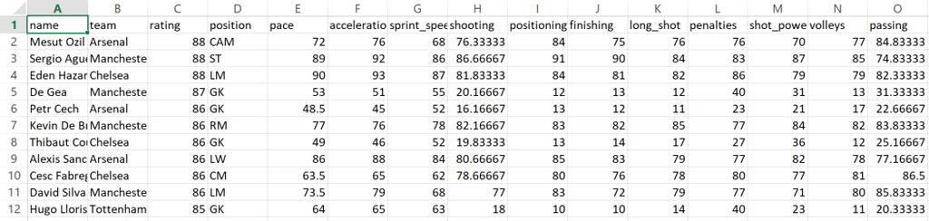

```python
from IPython.display import Image
Image("fifa-csv.png")
```

### Scraping League performance statistics

Next up, we got the performances for all the players in the Premier League (UK first division soccer league)

This translates to the "In Real Life" performance of the player, for 38 games during a season so one full year

You can find statistics related to a player's performance, such as amount of goals scored, on the official website

[figure not shown]

```python
from IPython.display import Image
Image("epl-player.png")
```

There are 4 four player cathegories, related to their positions on the field: Goalkeeper, Defender, Midfielder and Forward

Each category gets different statistics displayed - for instance the goalkeepers get information as to how many saves the y produce whereas forwards get info as to how many goals they score

The website is built on javascript, which means we had to use Selenium to "fake" a Chrome browser opening the website and clicking on elements manually

We scraped four seasons: 15/16, 16/17, 17/18 as well as the still ongoing 18/19

```python
#Helper function to get the statistics of a given player, depending on the position:
def get_info(epl_id,position,season):
    # create a new Chrome session
    driver = webdriver.Chrome(chrome_driver_path)
    response = driver.get('https://www.premierleague.com/players/'+epl_id+'/player/stats?co=1&se='+season)
    time.sleep(2)
    source = driver.page_source
    driver.quit()
    stat_list = []
    page_content = BeautifulSoup(source,'lxml')
    main = page_content.find('ul', class_='normalStatList block-list-2 block-list-2-m block-list-padding')
    stats = main.find_all('span')

    if position=='GOALKEEPER':
        for item in stats[1:16:2]+stats[18:25:2]+stats[27:32:2]+stats[34::2]:
            try:
                x = item.find('span').get_text()
                x = x.replace(',','')
                if "%" in x:
                    x = float(x.replace('%',''))/100
                else:
                    x = float(x)
                stat_list.append(x)

            #In case the data is missing, so we don't get an error that would stop the program from running
            except AttributeError:
                stat_list.append(0)
        return(stat_list)

    if position=='DEFENDER':
        for item in stats[1:36:2]+stats[38:53:2]+stats[55:62:2]+stats[64::2]:
            try:
                x = item.find('span').get_text()
                x = x.replace(',','')
                if "%" in x:
                    x = float(x.replace('%',''))/100
                else:
                    x = float(x)
                stat_list.append(x)

            except AttributeError:
                stat_list.append(0)
        return(stat_list)

    if position=='MIDFIELDER':
        for item in stats[1:24:2]+stats[26:41:2]+stats[43:50:2]+stats[52::2]:
            try:
                x = item.find('span').get_text()
                x = x.replace(',','')
                if "%" in x:
                    x = float(x.replace('%',''))/100
                else:
                    x = float(x)
                stat_list.append(x)

            except AttributeError:
                stat_list.append(0)
        return(stat_list)

    if position=='FORWARD':
        for item in stats[1:24:2]+stats[26:35:2]+stats[37:44:2]+stats[46::2]:
            try:
                x = item.find('span').get_text()
                x = x.replace(',','')
                if "%" in x:
                    x = float(x.replace('%',''))/100
                else:
                    x = float(x)
                stat_list.append(x)

            except AttributeError:
                stat_list.append(0)
        return(stat_list)
;
```

```python
#position is a str, can be one of:
#GOALKEEPER, DEFENDER, MIDFIELDER, FORWARD
#season is a strn can be one of:
#'27' is 2014/2015
#'42' is 2015/2016
#'54' is 2016/2017
#'79' is 2017/2018
#'210' is 2018/2019
def scrape_epl(position,season):
    driver = webdriver.Chrome(chrome_driver_path)
    response = driver.get("https://www.premierleague.com/stats/top/players/appearances?po="+position+"&se="+season)
    #Note that I chose Appearances as the statistic because if the players did not appear, then by definition their
    #stats are all zero
    time.sleep(10)
    source = driver.page_source
    page_content = BeautifulSoup(source,'lxml')
    name_list = []
    attributes = []

    #dismissing the cookies accept prompt:
    cookies_prompt = driver.find_element_by_css_selector('body > section > div > div > span')
    if (cookies_prompt != None):
        cookies_prompt.click()
        time.sleep(3)
    next_page_check = page_content.find('div',class_='paginationBtn paginationNextContainer')
    while next_page_check!=None:
        main = page_content.find('tbody', class_='statsTableContainer')
        players = main.find_all('a',class_='playerName')
        for player in players:
            name_list.append(player.get_text())
            epl_identifier = ''.join([n for n in player.get('href') if n.isdigit()])
            attributes.append(get_info(epl_identifier,position,season))
            #Then it clicks the next page button and goes to the next page
        next_button = driver.find_element_by_xpath('//*[@id="mainContent"]/div/div/div[2]/div[1]/div[3]/div[2]')
        ActionChains(driver).move_to_element(next_button).perform()
        next_button.click()
        time.sleep(10)
        source = driver.page_source
        page_content = BeautifulSoup(source,'lxml')
        next_page_check = page_content.find('div',class_='paginationBtn paginationNextContainer')
        #If this is the final page, it will go out of the loop
        #Otherwise it will go back to the top of the loop and fetch data frm the current page

    main = page_content.find('tbody', class_='statsTableContainer')
    players = main.find_all('a',class_='playerName')
    for player in players:
        name_list.append(player.get_text())
        epl_identifier = ''.join([n for n in player.get('href') if n.isdigit()])
        attributes.append(get_info(epl_identifier,position,season))

    driver.quit()

    attributes = list(zip(*attributes))
    dataset = list(zip(name_list, *attributes))

    return dataset
;
```

```python
def create_table(position,season):

    #get the dataset:
    dataset = scrape_epl(position,season)

    #naming the season properly:
    corresp = {'27':'2014_15','42':'2015_16','54':'2016_17','79':'2017_18','210':'2018_19'}
    years = corresp[season]

    #writing to a file
    file_name = years+'_'+position+"_stats.csv"
    with open(file_name, "w") as f:
        writer = csv.writer(f)
        if position == 'GOALKEEPER':
            writer.writerow(['name','saves','penalties saved','punches','high claims','catches','sweeper clearances','throw outs','goal kicks','clean sheets','goals conceded','errors leading to goal','own goals','yellow cards','red cards','fouls','goals','assists','passes','passes per match','accurate long balls'])
        if position == 'DEFENDER':
            writer.writerow(['name','clean sheets','goals conceded','tackles','tackle success','last man tackles','blocked shots','interceptions','clearances','headed clearance','clearances off line','recoveries','duels won','duels lost','successful 50/50','aerial battles won','aerial battles lost','own goals','errors leading to goal','assists','passes','passes per match','big chances created','crosses','cross accuracy','through balls','accurate long balls','yellow cards','red cards','fouls','offsides','goals','headed goals','goals with right foot','goals with left foot','hit woodwork'])
        if position == 'MIDFIELDER':
            writer.writerow(['name','goals', 'goals per match', 'headed goals', 'goals with right foot', 'goals with left foot', 'penalties scored', 'freekicks scored', 'shots', 'shots on target', 'shooting accuracy ', 'hit woodwork', 'big chances missed', 'assists', 'passes', 'passes per match', 'big chances created', 'crosses', 'cross accuracy', 'through balls', 'accurate long balls', 'yellow cards', 'red cards', 'fouls', 'offsides', 'tackles', 'tackle success', 'blocked shots', 'interceptions', 'clearances', 'headed clearance', 'recoveries', 'duels won', 'duels lost', 'successful 50/50', 'aerial battles won', 'aerial battles lost', 'errors leading to goal'])
        if position == 'FORWARD':
            writer.writerow(['name','goals', 'goals per match', 'headed goals', 'goals with right foot', 'goals with left foot', 'penalties scored', 'freekicks scored', 'shots', 'shots on target', 'shooting accuracy ', 'hit woodwork', 'big chances missed', 'assists', 'passes', 'passes per match', 'big chances created', 'crosses', 'yellow cards', 'red cards', 'fouls', 'offsides', 'tackles', 'blocked shots', 'interceptions', 'clearances', 'headed clearance'])
        writer.writerows(dataset)
;
```

```python
positions = ['GOALKEEPER', 'DEFENDER', 'MIDFIELDER', 'FORWARD']
seasons = ['42','54','79','210']

for seas in seasons:
    for pos in positions:
        create_table(pos,seas)
```

This means we had 4x4=16 csv files, four seasons times four player positions

The csv files look like this

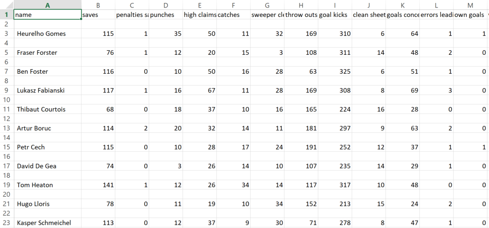

```python
from IPython.display import Image
Image("epl-csv.png")
```